# 1. Description

#### * The weighted tree model is also overfitting

## 4.6 Build a Tuned Bagging Classifier

#### Let's tune the bagging classifier with hyper parameters

```python
# grid search for bagging classifier
cl1 = DecisionTreeClassifier(class_weight={0:0.80,1:0.20},random_state=1)
param_grid = {'base_estimator':[cl1],
              'n_estimators':[5,7,15,51,101],
              'max_features': [0.7,0.8,0.9,1]
             }
grid = GridSearchCV(BaggingClassifier(random_state=1,bootstrap=True), param_grid=param_grid, scoring = 'recall', cv = 5)
grid.fit(X_train, y_train)
```

```
GridSearchCV(cv=5, estimator=BaggingClassifier(random_state=1),
             param_grid={'base_estimator': [DecisionTreeClassifier(class_weight={0: 0.8,
                                                                                 1: 0.2},
                                                                   random_state=1)],
                         'max_features': [0.7, 0.8, 0.9, 1],
                         'n_estimators': [5, 7, 15, 51, 101]},
             scoring='recall')
```

```python
## getting the best estimator
bagging_estimator  = grid.best_estimator_
bagging_estimator.fit(X_train,y_train)
```

```
BaggingClassifier(base_estimator=DecisionTreeClassifier(class_weight={0: 0.8,
                                                                      1: 0.2},
                                                        random_state=1),
                  max_features=0.9, n_estimators=101, random_state=1)
```

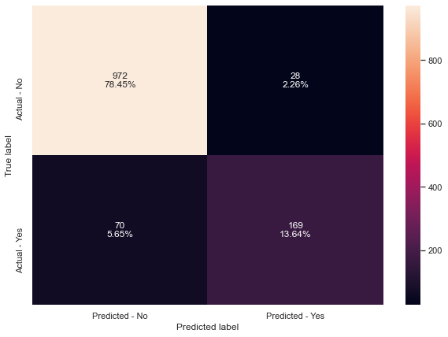

```python
# Get confusion matrix
make_confusion_matrix(bagging_estimator,y_test)
```

```python
# Get metrics
get_metrics_score(bagging_estimator)
```

```
Accuracy on training set :  1.0
Accuracy on test set :  0.9209039548022598
Recall on training set :  1.0
Recall on test set :  0.7071129707112971
Precision on training set :  1.0
Precision on test set :  0.8578680203045685
F1-Score on training set :  1.0
F1-Score on test set :  0.7752293577981652
```

```
[1.0,
 0.9209039548022598,
 1.0,
 0.7071129707112971,
 1.0,
 0.8578680203045685,
 1.0,
 0.7752293577981652]
```

#### * The hyper tuned bagging classifier overfits the model across Accuracy, Precision and Recall

## 4.7 Random Forest

```python
rf = RandomForestClassifier(random_state=1)
rf.fit(X_train,y_train)
```

```
RandomForestClassifier(random_state=1)
```

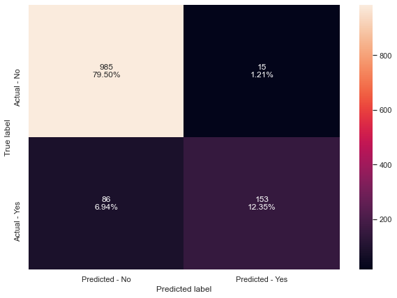

```python
make_confusion_matrix(rf,y_test)
```

```python
get_metrics_score(rf)
```

```
Accuracy on training set :  1.0
Accuracy on test set :  0.9184826472962067
Recall on training set :  1.0
Recall on test set :  0.6401673640167364
Precision on training set :  1.0
Precision on test set :  0.9107142857142857
F1-Score on training set :  1.0
F1-Score on test set :  0.7518427518427518
```

```
[1.0,
 0.9184826472962067,
 1.0,
 0.6401673640167364,
 1.0,
 0.9107142857142857,
 1.0,
 0.7518427518427518]
```

#### * Precision has increased, but the model still overfits

## 4.8 Random Forest with Class Weights

```python
rf_wt = RandomForestClassifier(class_weight={0:0.80,1:0.20}, random_state=1)
rf_wt.fit(X_train,y_train)
```

```
RandomForestClassifier(class_weight={0: 0.8, 1: 0.2}, random_state=1)
```

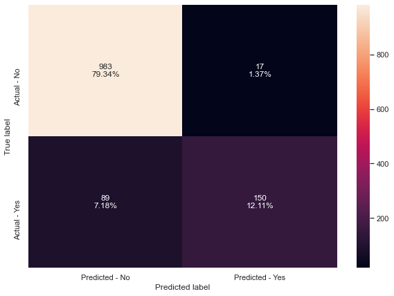

```python
make_confusion_matrix(rf_wt,y_test)
```

```python
get_metrics_score(rf_wt)
```

```
Accuracy on training set :  1.0
Accuracy on test set :  0.9144471347861178
Recall on training set :  1.0
Recall on test set :  0.6276150627615062
Precision on training set :  1.0
Precision on test set :  0.8982035928143712
F1-Score on training set :  1.0
F1-Score on test set :  0.7389162561576355
```

```
[1.0,
 0.9144471347861178,
 1.0,
 0.6276150627615062,
 1.0,
 0.8982035928143712,
 1.0,
 0.7389162561576355]
```

#### The weighted Random Tree also overfits - with not much difference compared to the regular Random Forest model

## 4.9 Build Tuned Random Forest

#### Let's try to tune the Random Forest model with hyper paramters

```python
# Choose the type of classifier.

rf_estimator = RandomForestClassifier(class_weight={0:0.80,1:0.20}, random_state=1)

# Grid of parameters to choose from
parameters = {
        "n_estimators": [110,251,501],
        "min_samples_leaf": np.arange(1, 6,1),
        "max_features": [0.7,0.9,'log2','auto'],
        "max_samples": [0.7,0.9,None],
}


# Run the grid search
grid_obj = GridSearchCV(rf_estimator, parameters, scoring='precision',cv=5)
grid_obj = grid_obj.fit(X_train, y_train)

# Set the clf to the best combination of parameters
rf_estimator = grid_obj.best_estimator_

# Fit the best algorithm to the data.
rf_estimator.fit(X_train, y_train)
```

```
RandomForestClassifier(class_weight={0: 0.8, 1: 0.2}, max_features='log2',
                       min_samples_leaf=5, n_estimators=110, random_state=1)
```

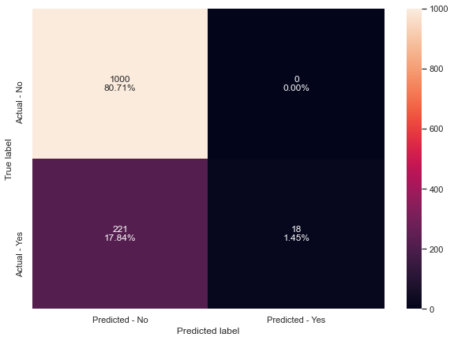

```python
# Make confusion matrix
make_confusion_matrix(rf_estimator,y_test)
```

```python
# Get performance metrics
get_metrics_score(rf_estimator)
```

```
Accuracy on training set :  0.8303911388023537
Accuracy on test set :  0.8216303470540759
Recall on training set :  0.12186379928315412
Recall on test set :  0.07531380753138076
Precision on training set :  1.0
Precision on test set :  1.0
F1-Score on training set :  0.21725239616613418
F1-Score on test set :  0.14007782101167315
```

```
[0.8303911388023537,
 0.8216303470540759,
 0.12186379928315412,
 0.07531380753138076,
 1.0,
 1.0,
 0.21725239616613418,
 0.14007782101167315]
```

## 4.10 Model Comparisons

```python
# defining list of models
bagging_models = [dtree,dtree_estimator,bagging,bagging_wt,bagging_estimator,rf,rf_wt,rf_estimator]

# defining empty lists to add train and test results
acc_train = []
acc_test = []
recall_train = []
recall_test = []
precision_train = []
precision_test = []
f1_train = []
f1_test = []

# looping through all the models to get the metrics score - Accuracy, Recall and Precision
for model in bagging_models:

    j = get_metrics_score(model,False)
    acc_train.append(j[0])
    acc_test.append(j[1])
    recall_train.append(j[2])
    recall_test.append(j[3])
    precision_train.append(j[4])
    precision_test.append(j[5])
    f1_train.append(j[6])
    f1_test.append(j[7])


bagging_comparison_frame = pd.DataFrame({'Model':['Decision Tree','Tuned Decision Tree','Bagging Classifier',
                                          'Weighted Bagging Classifier','Tuned Bagging Classifier',
                                          'Random Forest','Weighted Random Forest','Tuned Random Forest'],
                                          'Train_Accuracy': acc_train,
                                          'Test_Accuracy': acc_test,
                                          'Train_Recall': recall_train,
                                          'Test_Recall': recall_test,
                                          'Train_Precision': precision_train,
                                          'Test_Precision': precision_test,
                                        'Train_F1-Score':f1_train, 'Test_F1-Score':f1_test})
```

```python
bagging_comparison_frame.sort_values(by='Test_F1-Score',ascending=False)
```

|  | Model | Train_Accuracy | Test_Accuracy | Train_Recall | Test_Recall | Train_Precision | Test_Precision | Train_F1-Score | Test_F1-Score |
| --- | --- | --- | --- | --- | --- | --- | --- | --- | --- |
| 4 | Tuned Bagging Classifier | 1.000000 | 0.920904 | 1.000000 | 0.707113 | 1.000000 | 0.857868 | 1.000000 | 0.775229 |
| 5 | Random Forest | 1.000000 | 0.918483 | 1.000000 | 0.640167 | 1.000000 | 0.910714 | 1.000000 | 0.751843 |
| 0 | Decision Tree | 1.000000 | 0.901533 | 1.000000 | 0.753138 | 1.000000 | 0.740741 | 1.000000 | 0.746888 |
| 6 | Weighted Random Forest | 1.000000 | 0.914447 | 1.000000 | 0.627615 | 1.000000 | 0.898204 | 1.000000 | 0.738916 |
| 2 | Bagging Classifier | 0.993769 | 0.907183 | 0.969534 | 0.644351 | 0.998155 | 0.836957 | 0.983636 | 0.728132 |
| 3 | Weighted Bagging Classifier | 0.994808 | 0.905569 | 0.974910 | 0.644351 | 0.998165 | 0.827957 | 0.986401 | 0.724706 |
| 1 | Tuned Decision Tree | 0.828314 | 0.820016 | 0.118280 | 0.104603 | 0.942857 | 0.735294 | 0.210191 | 0.183150 |
| 7 | Tuned Random Forest | 0.830391 | 0.821630 | 0.121864 | 0.075314 | 1.000000 | 1.000000 | 0.217252 | 0.140078 |

## 4.11 Feature importance of Bagging Classifier

```python
# importance of features in the tree building ( The importance of a feature is computed as the
#(normalized) total reduction of the criterion brought by that feature. It is also known as the Gini importance )

print (pd.DataFrame(bagging.feature_importances_, columns = ["Imp"], index = X_train.columns).sort_values(by = 'Imp', ascending = False))
```

```
                                  Imp
Age                          0.147641
DurationOfPitch              0.126149
MonthlyIncome                0.117953
Passport_1                   0.078788
Designation_Executive        0.074998
PitchSatisfactionScore       0.062191
NumberOfFollowups            0.050027
NumberOfTrips                0.043089
PreferredPropertyStar        0.034103
CityTier_3                   0.033317
MaritalStatus_Single         0.026089
NumberOfChildrenVisiting     0.021654
TypeofContact_Self Enquiry   0.021365
MaritalStatus_Married        0.019777
Occupation_Large Business    0.018943
MaritalStatus_Unmarried      0.018390
NumberOfPersonVisiting       0.017996
Gender_Male                  0.017677
Occupation_Salaried          0.013399
OwnCar_1                     0.012649
ProductPitched_Standard      0.010036
Occupation_Small Business    0.008931
CityTier_2                   0.007637
Designation_Senior Manager   0.004348
Designation_VP               0.003325
ProductPitched_Super Deluxe  0.002796
Designation_Manager          0.002772
ProductPitched_King          0.002295
ProductPitched_Deluxe        0.001666
```

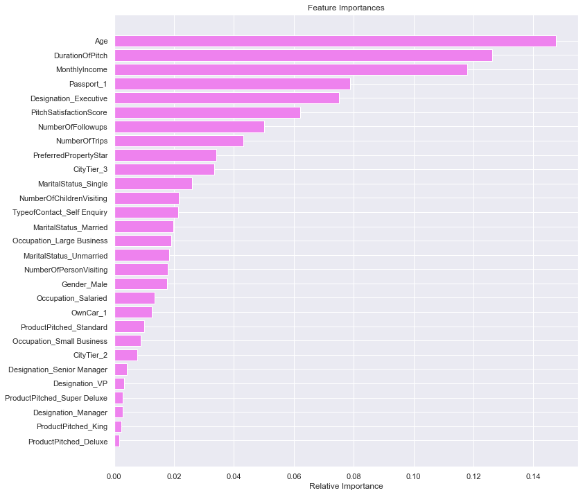

```python
importances = bagging.feature_importances_
indices = np.argsort(importances)

plt.figure(figsize=(12,12))
plt.title('Feature Importances')
plt.barh(range(len(indices)), importances[indices], color='violet', align='center')
plt.yticks(range(len(indices)), [feature_names[i] for i in indices])
plt.xlabel('Relative Importance')
plt.show()
```

## 4.12 Conclusion

# 5. Bosting models

## 5.1 AdaBooster Classifier

```python
abc = AdaBoostClassifier(random_state=1)
abc.fit(X_train,y_train)
```

```
AdaBoostClassifier(random_state=1)
```

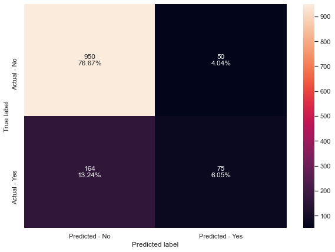

```python
make_confusion_matrix(abc,y_test)
```

```python
get_metrics_score(abc)
```

```
Accuracy on training set :  0.8549671166493596
Accuracy on test set :  0.8272800645682001
Recall on training set :  0.4050179211469534
Recall on test set :  0.3138075313807531
Precision on training set :  0.7220447284345048
Precision on test set :  0.6
F1-Score on training set :  0.51894374282434
F1-Score on test set :  0.41208791208791207
```

```
[0.8549671166493596,
 0.8272800645682001,
 0.4050179211469534,
 0.3138075313807531,
 0.7220447284345048,
 0.6,
 0.51894374282434,
 0.41208791208791207]
```

#### Ada Booster does not overfit like bagging models, but the overall performance as measured by precision and F1-score is poor

## 5.2 Tuned AdaBooster

```python
# Choose the type of classifier.
abc_tuned = AdaBoostClassifier(random_state=1)

# Grid of parameters to choose from
## add from article
parameters = {
    #Let's try different max_depth for base_estimator
    "base_estimator":[DecisionTreeClassifier(max_depth=1),
                      DecisionTreeClassifier(max_depth=2),
                      DecisionTreeClassifier(max_depth=3),
                      DecisionTreeClassifier(max_depth=4)],
    "n_estimators": np.arange(10,110,10),
    "learning_rate":np.arange(0.1,2,0.1)
}

# Type of scoring used to compare parameter combinations
acc_scorer = metrics.make_scorer(metrics.precision_score)

# Run the grid search
grid_obj = GridSearchCV(abc_tuned, parameters, scoring=acc_scorer,cv=5)
grid_obj = grid_obj.fit(X_train, y_train)

# Set the clf to the best combination of parameters
abc_tuned = grid_obj.best_estimator_

# Fit the best algorithm to the data.
abc_tuned.fit(X_train, y_train)
```

```
AdaBoostClassifier(base_estimator=DecisionTreeClassifier(max_depth=1),
                   learning_rate=0.4, n_estimators=10, random_state=1)
```

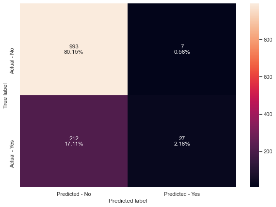

```python
make_confusion_matrix(abc_tuned,y_test)
```

```python
get_metrics_score(abc_tuned)
```

```
Accuracy on training set :  0.8213914849428868
Accuracy on test set :  0.8232445520581114
Recall on training set :  0.0985663082437276
Recall on test set :  0.11297071129707113
Precision on training set :  0.8088235294117647
Precision on test set :  0.7941176470588235
F1-Score on training set :  0.17571884984025557
F1-Score on test set :  0.19780219780219782
```

```
[0.8213914849428868,
 0.8232445520581114,
 0.0985663082437276,
 0.11297071129707113,
 0.8088235294117647,
 0.7941176470588235,
 0.17571884984025557,
 0.19780219780219782]
```

#### Hyper tuning on tree depth and n_estimators results in a much better precision scores but at a severe expense of recall. If the cost of incorrectly identifying a customer is low as will be the case with online marketing - this can be a good model to use

## 5.3 Gradient Boosting Classifier

```python
gbc = GradientBoostingClassifier(random_state=1)
gbc.fit(X_train,y_train)
```

```
GradientBoostingClassifier(random_state=1)
```

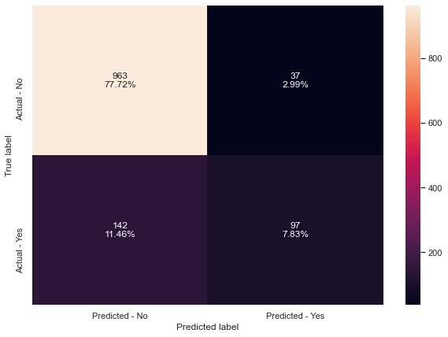

```python
make_confusion_matrix(gbc,y_test)
```

```python
get_metrics_score(gbc)
```

```
Accuracy on training set :  0.8985808238144687
Accuracy on test set :  0.8555286521388217
Recall on training set :  0.543010752688172
Recall on test set :  0.40585774058577406
Precision on training set :  0.8885630498533724
Precision on test set :  0.7238805970149254
F1-Score on training set :  0.6740823136818687
F1-Score on test set :  0.520107238605898
```

```
[0.8985808238144687,
 0.8555286521388217,
 0.543010752688172,
 0.40585774058577406,
 0.8885630498533724,
 0.7238805970149254,
 0.6740823136818687,
 0.520107238605898]
```

#### Overall performance of the Gradient Booster seems to be better than hyper tuned Ada Booster. The F1-scores have impored - but still at about 51% - is not great

## 5.4 Tuned GradientBooster

```python
# Choose the type of classifier.
gbc_tuned = GradientBoostingClassifier(init=AdaBoostClassifier(random_state=1),random_state=1)

# Grid of parameters to choose from
parameters = {
    "n_estimators": [100,150,200,250],
    "subsample":[0.8,0.9,1],
    "max_features":[0.7,0.8,0.9,1]
}

# Type of scoring used to compare parameter combinations
scorer = metrics.make_scorer(metrics.precision_score)

# Run the grid search
grid_obj = GridSearchCV(gbc_tuned, parameters, scoring=scorer,cv=5)
grid_obj = grid_obj.fit(X_train, y_train)

# Set the clf to the best combination of parameters
gbc_tuned = grid_obj.best_estimator_

# Fit the best algorithm to the data.
gbc_tuned.fit(X_train, y_train)
```

```
GradientBoostingClassifier(init=AdaBoostClassifier(random_state=1),
                           max_features=0.7, n_estimators=250, random_state=1,
                           subsample=0.9)
```

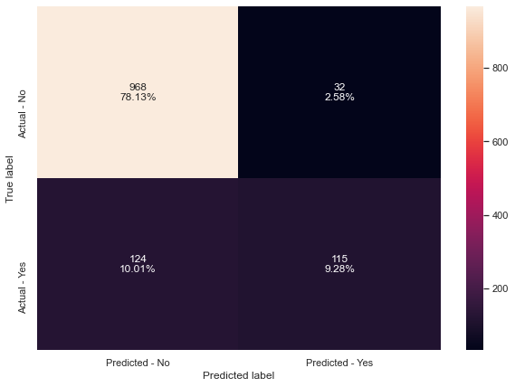

```python
make_confusion_matrix(gbc_tuned,y_test)
```

```python
get_metrics_score(gbc_tuned)
```

```
Accuracy on training set :  0.9394254067151263
Accuracy on test set :  0.87409200968523
Recall on training set :  0.7150537634408602
Recall on test set :  0.4811715481171548
Precision on training set :  0.9614457831325302
Precision on test set :  0.782312925170068
F1-Score on training set :  0.8201438848920864
F1-Score on test set :  0.5958549222797926
```

```
[0.9394254067151263,
 0.87409200968523,
 0.7150537634408602,
 0.4811715481171548,
 0.9614457831325302,
 0.782312925170068,
 0.8201438848920864,
 0.5958549222797926]
```

#### Hypertuning Gradient Booster on n_samples and results in a model that over fits precision .

## 5.5 XGBoost Boosting Classifier

```python
xgb = XGBClassifier(random_state=1)
xgb.fit(X_train,y_train)
```

```
[16:35:38] WARNING: ..\src\learner.cc:1061: Starting in XGBoost 1.3.0, the default evaluation metric used with the objective 'binary:logistic' was changed from 'error' to 'logloss'. Explicitly set eval_metric if you'd like to restore the old behavior.
```

```
XGBClassifier(base_score=0.5, booster='gbtree', colsample_bylevel=1,
              colsample_bynode=1, colsample_bytree=1, gamma=0, gpu_id=-1,
              importance_type='gain', interaction_constraints='',
              learning_rate=0.300000012, max_delta_step=0, max_depth=6,
              min_child_weight=1, missing=nan, monotone_constraints='()',
              n_estimators=100, n_jobs=8, num_parallel_tree=1, random_state=1,
              reg_alpha=0, reg_lambda=1, scale_pos_weight=1, subsample=1,
              tree_method='exact', validate_parameters=1, verbosity=None)
```

[figure not shown]

```python
make_confusion_matrix(gbc,y_test)
```

```python
get_metrics_score(xgb)
```

```
Accuracy on training set :  0.9996538594669436
Accuracy on test set :  0.9297820823244553
Recall on training set :  0.9982078853046595
Recall on test set :  0.7154811715481172
Precision on training set :  1.0
Precision on test set :  0.9
F1-Score on training set :  0.9991031390134528
F1-Score on test set :  0.7972027972027973
```

```
[0.9996538594669436,
 0.9297820823244553,
 0.9982078853046595,
 0.7154811715481172,
 1.0,
 0.9,
 0.9991031390134528,
 0.7972027972027973]
```

#### * A regular XGBoost model is overfitting on the critical Precision scores

## 5.6 XGBoost - Hyperparameter Tuning

```python
# Choose the type of classifier.
xgb_tuned = XGBClassifier(random_state=1, eval_metric='mlogloss')

# Grid of parameters to choose from
## add from
parameters = {
    "n_estimators": [50,100,150],
    "max_depth":[6],
    "scale_pos_weight":[0,1,2,5],
    "subsample":[0.5,0.7,0.9,1],
    "learning_rate":[0.01,0.05, 0.1],
    "gamma":[0,1],
    "colsample_bytree":[0.7,0.9],
    "colsample_bylevel":[0.7,0.9]
}

# Type of scoring used to compare parameter combinations
acc_scorer = metrics.make_scorer(metrics.precision_score)

# Run the grid search
grid_obj = GridSearchCV(xgb_tuned, parameters,scoring=acc_scorer,cv=5)
grid_obj = grid_obj.fit(X_train, y_train)

# Set the clf to the best combination of parameters
xgb_tuned = grid_obj.best_estimator_

# Fit the best algorithm to the data.
xgb_tuned.fit(X_train, y_train)
```

```
XGBClassifier(base_score=0.5, booster='gbtree', colsample_bylevel=0.7,
              colsample_bynode=1, colsample_bytree=0.7, eval_metric='mlogloss',
              gamma=0, gpu_id=-1, importance_type='gain',
              interaction_constraints='', learning_rate=0.05, max_delta_step=0,
              max_depth=6, min_child_weight=1, missing=nan,
              monotone_constraints='()', n_estimators=150, n_jobs=8,
              num_parallel_tree=1, random_state=1, reg_alpha=0, reg_lambda=1,
              scale_pos_weight=1, subsample=1, tree_method='exact',
              validate_parameters=1, verbosity=None)
```

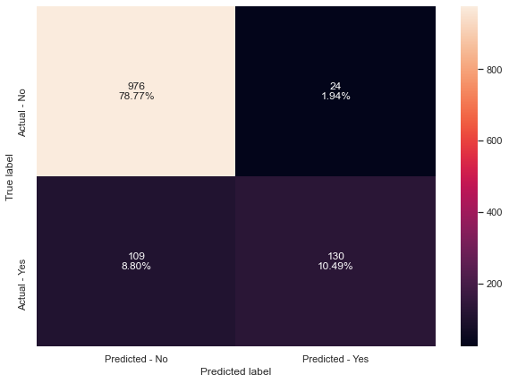

```python
make_confusion_matrix(xgb_tuned,y_test)
```

```python
get_metrics_score(xgb_tuned)
```

```
Accuracy on training set :  0.96711664935964
Accuracy on test set :  0.8926553672316384
Recall on training set :  0.8369175627240143
Recall on test set :  0.5439330543933054
Precision on training set :  0.9915074309978769
Precision on test set :  0.8441558441558441
F1-Score on training set :  0.9076773566569486
F1-Score on test set :  0.6615776081424937
```

```
[0.96711664935964,
 0.8926553672316384,
 0.8369175627240143,
 0.5439330543933054,
 0.9915074309978769,
 0.8441558441558441,
 0.9076773566569486,
 0.6615776081424937]
```

#### Hypertuning XGBoost on n_estimators, tree depth does not solve the overfitting problem

## 5.7 Stacking Classifier

```python
estimators = [('Bagging Tuned',bagging_estimator), ('Gradient Boosting',gbc_tuned), ('Ada Boost Tuned',abc_tuned)]

final_estimator = xgb_tuned

stacking_classifier= StackingClassifier(estimators=estimators,final_estimator=final_estimator)

stacking_classifier.fit(X_train,y_train)
```

```
StackingClassifier(estimators=[('Bagging Tuned',
                                BaggingClassifier(base_estimator=DecisionTreeClassifier(class_weight={0: 0.8,
                                                                                                      1: 0.2},
                                                                                        random_state=1),
                                                  max_features=0.9,
                                                  n_estimators=101,
                                                  random_state=1)),
                               ('Gradient Boosting',
                                GradientBoostingClassifier(init=AdaBoostClassifier(random_state=1),
                                                           max_features=0.7,
                                                           n_estimators=250,
                                                           random_state=1,
                                                           subsample=0.9)),
                               (...
                                                 eval_metric='mlogloss',
                                                 gamma=0, gpu_id=-1,
                                                 importance_type='gain',
                                                 interaction_constraints='',
                                                 learning_rate=0.05,
                                                 max_delta_step=0, max_depth=6,
                                                 min_child_weight=1,
                                                 missing=nan,
                                                 monotone_constraints='()',
                                                 n_estimators=150, n_jobs=8,
                                                 num_parallel_tree=1,
                                                 random_state=1, reg_alpha=0,
                                                 reg_lambda=1,
                                                 scale_pos_weight=1,
                                                 subsample=1,
                                                 tree_method='exact',
                                                 validate_parameters=1,
                                                 verbosity=None))
```

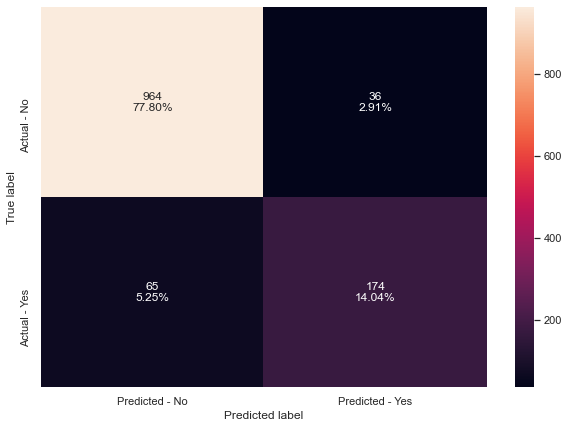

```python
# Get confusion matrix
make_confusion_matrix(stacking_classifier,y_test)
```

```python
# Get scores
get_metrics_score(stacking_classifier)
```

```
Accuracy on training set :  0.9996538594669436
Accuracy on test set :  0.9184826472962067
Recall on training set :  1.0
Recall on test set :  0.7280334728033473
Precision on training set :  0.998211091234347
Precision on test set :  0.8285714285714286
F1-Score on training set :  0.9991047448522828
F1-Score on test set :  0.7750556792873052
```

```
[0.9996538594669436,
 0.9184826472962067,
 1.0,
 0.7280334728033473,
 0.998211091234347,
 0.8285714285714286,
 0.9991047448522828,
 0.7750556792873052]
```

## 5.8 Comparing Boosting Models

```python
# defining list of models
boosting_models = [abc,gbc,xgb,abc_tuned,gbc_tuned,xgb_tuned, stacking_classifier]

# defining empty lists to add train and test results
boost_acc_train = []
boost_acc_test = []
boost_recall_train = []
boost_recall_test = []
boost_precision_train = []
boost_precision_test = []
boost_f1_train = []
boost_f1_test = []

# looping through all the models to get the metrics score - Accuracy, Recall and Precision
for model in boosting_models:

    j = get_metrics_score(model,False)
    boost_acc_train.append(j[0])
    boost_acc_test.append(j[1])
    boost_recall_train.append(j[2])
    boost_recall_test.append(j[3])
    boost_precision_train.append(j[4])
    boost_precision_test.append(j[5])
    boost_f1_train.append(j[6])
    boost_f1_test.append(j[7])


boosting_comparison_frame = pd.DataFrame({'Model':['Ada Boosting','Gradient Boosting','XGBoosting',
                                          'Ada Boosting - Tuned','Gradient Boosting - Tuned', 'XGBoosting - Tuned', 'Stacking'],
                                          'Train_Accuracy': boost_acc_train,
                                          'Test_Accuracy': boost_acc_test,
                                          'Train_Recall': boost_recall_train,
                                          'Test_Recall': boost_recall_test,
                                          'Train_Precision': boost_precision_train,
                                          'Test_Precision': boost_precision_test,
                                        'Train_F1-Score':boost_f1_train, 'Test_F1-Score':boost_f1_test})
```

```python
boosting_comparison_frame.sort_values(by='Test_F1-Score',ascending=False)
```

|  | Model | Train_Accuracy | Test_Accuracy | Train_Recall | Test_Recall | Train_Precision | Test_Precision | Train_F1-Score | Test_F1-Score |
| --- | --- | --- | --- | --- | --- | --- | --- | --- | --- |
| 2 | XGBoosting | 0.999654 | 0.929782 | 0.998208 | 0.715481 | 1.000000 | 0.900000 | 0.999103 | 0.797203 |
| 6 | Stacking | 0.999654 | 0.918483 | 1.000000 | 0.728033 | 0.998211 | 0.828571 | 0.999105 | 0.775056 |
| 5 | XGBoosting - Tuned | 0.967117 | 0.892655 | 0.836918 | 0.543933 | 0.991507 | 0.844156 | 0.907677 | 0.661578 |
| 4 | Gradient Boosting - Tuned | 0.939425 | 0.874092 | 0.715054 | 0.481172 | 0.961446 | 0.782313 | 0.820144 | 0.595855 |
| 1 | Gradient Boosting | 0.898581 | 0.855529 | 0.543011 | 0.405858 | 0.888563 | 0.723881 | 0.674082 | 0.520107 |
| 0 | Ada Boosting | 0.854967 | 0.827280 | 0.405018 | 0.313808 | 0.722045 | 0.600000 | 0.518944 | 0.412088 |
| 3 | Ada Boosting - Tuned | 0.821391 | 0.823245 | 0.098566 | 0.112971 | 0.808824 | 0.794118 | 0.175719 | 0.197802 |

#### Observations

1. XGBoost model is overfitting
2. Stacking is also an overfitting mdodel
3. Tuned XGBoost model gives good precision performance and a decent enough F1 score which will minimize the cost of Type2 error. This model seems to be a godo compromise.
4. Other models (Gradient & Ada boosting) dont give good enough precision performance for consideration.
5. Therefore - among boosting models - we recommend using the Hypertuned XGB Boost model

## 5.9 Relative importance of Tuned XGBoost model

```python
print (pd.DataFrame(xgb_tuned.feature_importances_, columns = ["Imp"], index = X_train.columns).sort_values(by = 'Imp', ascending = False))
```

```
                                  Imp
Passport_1                   0.137815
Designation_Executive        0.094504
MaritalStatus_Single         0.059588
CityTier_3                   0.049191
MaritalStatus_Unmarried      0.041279
Occupation_Large Business    0.037611
Age                          0.034891
MonthlyIncome                0.031699
Designation_Manager          0.031150
MaritalStatus_Married        0.031085
NumberOfFollowups            0.030137
ProductPitched_Deluxe        0.029992
CityTier_2                   0.029239
PreferredPropertyStar        0.029091
PitchSatisfactionScore       0.027985
DurationOfPitch              0.027790
ProductPitched_Standard      0.027682
TypeofContact_Self Enquiry   0.027124
NumberOfTrips                0.026497
Gender_Male                  0.023493
ProductPitched_Super Deluxe  0.022900
Designation_Senior Manager   0.022414
OwnCar_1                     0.021347
Occupation_Salaried          0.021257
NumberOfPersonVisiting       0.020467
Occupation_Small Business    0.018760
ProductPitched_King          0.017954
NumberOfChildrenVisiting     0.017524
Designation_VP               0.009532
```

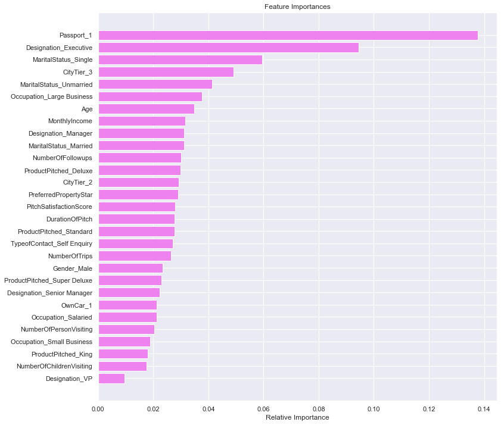

```python
importances = xgb_tuned.feature_importances_
indices = np.argsort(importances)

plt.figure(figsize=(12,12))
plt.title('Feature Importances')
plt.barh(range(len(indices)), importances[indices], color='violet', align='center')
plt.yticks(range(len(indices)), [feature_names[i] for i in indices])
plt.xlabel('Relative Importance')
plt.show()
```

## 5.10 Conclusion

- Bucket 1 variables - We can see that Passport, Executive designation, Single status, City tier and Unmarried staus are leading factrs that determine package purchase
- Bucket 2 - In this model - all other subsequent variables play an almost equal importance.
- We recommend to the marketing team to identify customers based on the first bucket of variables. All other variables seem to have about equal payoff.